# PCAs of mC in 100 kbp bins

### Correlation between PC1 and %mC by chromatin

After spliting Euchromatin bins from Heterochromatin bins the correlation between PC1 and %mCG is only visible for the heterochromatin. For euchromatin there seems to be no connection (I checked other PCs up unitl PC5 and none of them reflect the %mC), even though the samples clearly separate by methylation level.

For CHG and CHH the correlation is much stronger in Heterochromatin, but it is still apparent for Euchromatin

#### CG

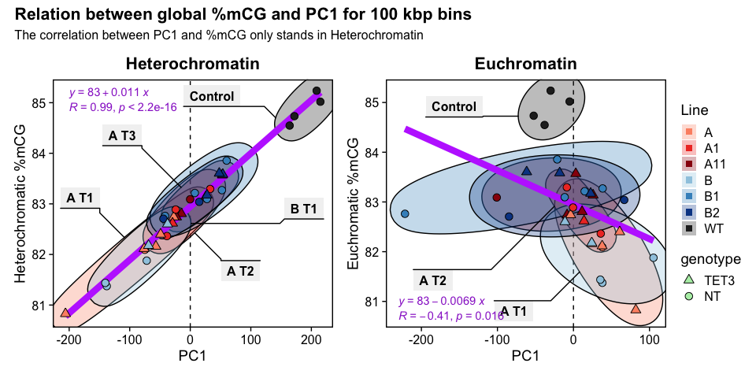

#### CHG

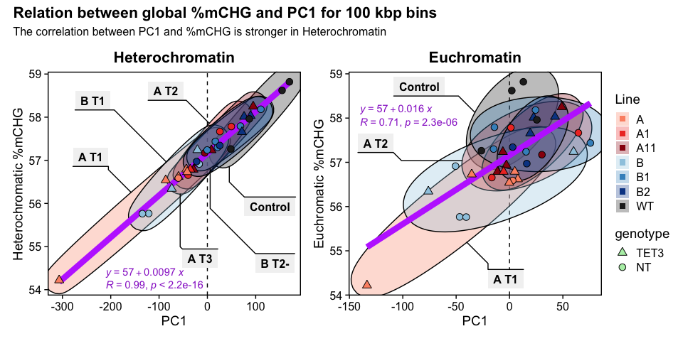

#### CHH

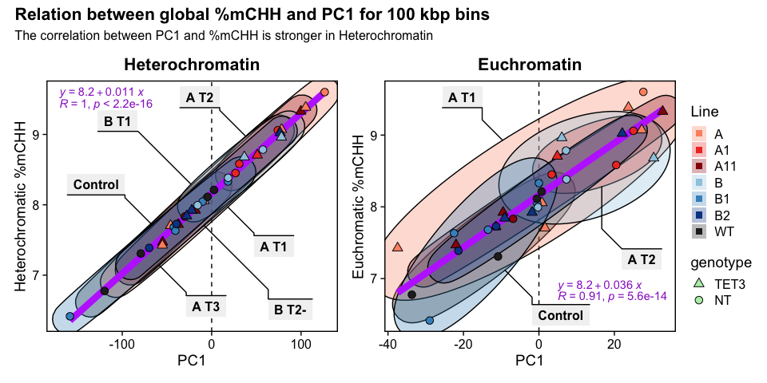

## variance by chromatin

Check how many of the 5000 windows with the most variation are hetero vs euchromatic

| chromatin | n | percent | total |
| --- | --- | --- | --- |
| Euchromatin | 1658 | 0.332198 | 4991 |
| Heterochromatin | 3333 | 0.667802 | 4991 |

Versus the whole set of bins

| chromatin | n | percent | total |
| --- | --- | --- | --- |
| Euchromatin | 1827 | 0.2333631 | 7829 |
| Heterochromatin | 6002 | 0.7666369 | 7829 |

In the 5000 more variable there is an enrichment in Euchromatin, even though in eucrhomatin there is no pattern.

To check the distribution better I did a raincloud plot , the there seems to be significantly more variation in methylation rates in the Euchromatin, but the bins that are the most variable are Heterochromatic.

I’m not entirely sure if this last bit is of any use, but I managed to get a nice plot.

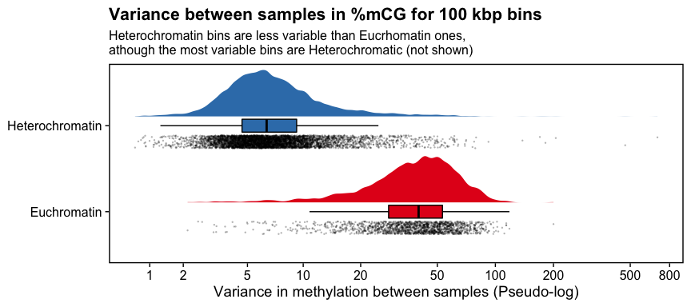